# PART I: German Credit Score Classification Model EDA

#### By: Krishna J

## Importing necessary libraries

```python
import pandas as pd
import numpy as np
import seaborn               as sns
import matplotlib.pyplot     as plt
import shap
import eli5
from sklearn.model_selection import train_test_split
#from sklearn.ensemble        import RandomForestClassifier
#from sklearn.linear_model    import LogisticRegression
from sklearn.preprocessing   import MinMaxScaler, StandardScaler
from sklearn.base            import TransformerMixin
from sklearn.pipeline        import Pipeline, FeatureUnion
from typing                  import List, Union, Dict
# Warnings will be used to silence various model warnings for tidier output
import warnings
warnings.filterwarnings('ignore')
%matplotlib inline
from IPython.core.interactiveshell import InteractiveShell
InteractiveShell.ast_node_interactivity = "all"
np.random.seed(0)
```

```
pandas.util.testing is deprecated. Use the functions in the public API at pandas.testing instead.
```

## Importing the source dataset

Source:

https://archive.ics.uci.edu/ml/datasets/Statlog+%28German+Credit+Data%29

Professor Dr. Hans Hofmann Institut f"ur Statistik und "Okonometrie Universit"at Hamburg FB Wirtschaftswissenschaften Von-Melle-Park 5 2000 Hamburg 13

```python
feature_list = ['CurrentAcc', 'NumMonths', 'CreditHistory', 'Purpose', 'CreditAmount',
         'Savings', 'EmployDuration', 'PayBackPercent', 'Gender', 'Debtors',
         'ResidenceDuration', 'Collateral', 'Age', 'OtherPayBackPlan', 'Property',
         'ExistingCredit', 'Job', 'Dependents', 'Telephone', 'Foreignworker', 'CreditStatus']

german_xai = pd.read_csv('C:/Users/krish/Downloads/german.data.txt',names = feature_list, delimiter=' ')
```

```python
german_xai.head()
```

|  | CurrentAcc | NumMonths | CreditHistory | Purpose | CreditAmount | Savings | EmployDuration | PayBackPercent | Gender | Debtors | ... | Collateral | Age | OtherPayBackPlan | Property | ExistingCredit | Job | Dependents | Telephone | Foreignworker | CreditStatus |
| --- | --- | --- | --- | --- | --- | --- | --- | --- | --- | --- | --- | --- | --- | --- | --- | --- | --- | --- | --- | --- | --- |
| 0 | A11 | 6 | A34 | A43 | 1169 | A65 | A75 | 4 | A93 | A101 | ... | A121 | 67 | A143 | A152 | 2 | A173 | 1 | A192 | A201 | 1 |
| 1 | A12 | 48 | A32 | A43 | 5951 | A61 | A73 | 2 | A92 | A101 | ... | A121 | 22 | A143 | A152 | 1 | A173 | 1 | A191 | A201 | 2 |
| 2 | A14 | 12 | A34 | A46 | 2096 | A61 | A74 | 2 | A93 | A101 | ... | A121 | 49 | A143 | A152 | 1 | A172 | 2 | A191 | A201 | 1 |
| 3 | A11 | 42 | A32 | A42 | 7882 | A61 | A74 | 2 | A93 | A103 | ... | A122 | 45 | A143 | A153 | 1 | A173 | 2 | A191 | A201 | 1 |
| 4 | A11 | 24 | A33 | A40 | 4870 | A61 | A73 | 3 | A93 | A101 | ... | A124 | 53 | A143 | A153 | 2 | A173 | 2 | A191 | A201 | 2 |

5 rows × 21 columns

```python
german_xai.shape
```

```
(1000, 21)
```

The dataset has 1000 entries with 21 fields.

```python
type(german_xai)
```

```
pandas.core.frame.DataFrame
```

```python
german_xai.head(10)

german_xai.columns
```

|  | CurrentAcc | NumMonths | CreditHistory | Purpose | CreditAmount | Savings | EmployDuration | PayBackPercent | Gender | Debtors | ... | Collateral | Age | OtherPayBackPlan | Property | ExistingCredit | Job | Dependents | Telephone | Foreignworker | CreditStatus |
| --- | --- | --- | --- | --- | --- | --- | --- | --- | --- | --- | --- | --- | --- | --- | --- | --- | --- | --- | --- | --- | --- |
| 0 | A11 | 6 | A34 | A43 | 1169 | A65 | A75 | 4 | A93 | A101 | ... | A121 | 67 | A143 | A152 | 2 | A173 | 1 | A192 | A201 | 1 |
| 1 | A12 | 48 | A32 | A43 | 5951 | A61 | A73 | 2 | A92 | A101 | ... | A121 | 22 | A143 | A152 | 1 | A173 | 1 | A191 | A201 | 2 |
| 2 | A14 | 12 | A34 | A46 | 2096 | A61 | A74 | 2 | A93 | A101 | ... | A121 | 49 | A143 | A152 | 1 | A172 | 2 | A191 | A201 | 1 |
| 3 | A11 | 42 | A32 | A42 | 7882 | A61 | A74 | 2 | A93 | A103 | ... | A122 | 45 | A143 | A153 | 1 | A173 | 2 | A191 | A201 | 1 |
| 4 | A11 | 24 | A33 | A40 | 4870 | A61 | A73 | 3 | A93 | A101 | ... | A124 | 53 | A143 | A153 | 2 | A173 | 2 | A191 | A201 | 2 |
| 5 | A14 | 36 | A32 | A46 | 9055 | A65 | A73 | 2 | A93 | A101 | ... | A124 | 35 | A143 | A153 | 1 | A172 | 2 | A192 | A201 | 1 |
| 6 | A14 | 24 | A32 | A42 | 2835 | A63 | A75 | 3 | A93 | A101 | ... | A122 | 53 | A143 | A152 | 1 | A173 | 1 | A191 | A201 | 1 |
| 7 | A12 | 36 | A32 | A41 | 6948 | A61 | A73 | 2 | A93 | A101 | ... | A123 | 35 | A143 | A151 | 1 | A174 | 1 | A192 | A201 | 1 |
| 8 | A14 | 12 | A32 | A43 | 3059 | A64 | A74 | 2 | A91 | A101 | ... | A121 | 61 | A143 | A152 | 1 | A172 | 1 | A191 | A201 | 1 |
| 9 | A12 | 30 | A34 | A40 | 5234 | A61 | A71 | 4 | A94 | A101 | ... | A123 | 28 | A143 | A152 | 2 | A174 | 1 | A191 | A201 | 2 |

10 rows × 21 columns

```
Index(['CurrentAcc', 'NumMonths', 'CreditHistory', 'Purpose', 'CreditAmount',
       'Savings', 'EmployDuration', 'PayBackPercent', 'Gender', 'Debtors',
       'ResidenceDuration', 'Collateral', 'Age', 'OtherPayBackPlan',
       'Property', 'ExistingCredit', 'Job', 'Dependents', 'Telephone',
       'Foreignworker', 'CreditStatus'],
      dtype='object')
```

List of fields in the source dataset are listed above

```python
german_xai.dtypes
```

```
CurrentAcc           object
NumMonths             int64
CreditHistory        object
Purpose              object
CreditAmount          int64
Savings              object
EmployDuration       object
PayBackPercent        int64
Gender               object
Debtors              object
ResidenceDuration     int64
Collateral           object
Age                   int64
OtherPayBackPlan     object
Property             object
ExistingCredit        int64
Job                  object
Dependents            int64
Telephone            object
Foreignworker        object
CreditStatus          int64
dtype: object
```

Datatypes of each field is displayed above

#### Missing Value Check

```python
import klib
klib.missingval_plot(german_xai)
```

```
No missing values found in the dataset.
```

## Feature Engineering

Dropping the unnecessary fields and fields that has constant value. From given data, CurrentAcc is the attribute that stores the information related to status of checking the account details. Let us drop this field since it is not related to credit score being good or bad.

```python
german_xai.drop(['CurrentAcc'],inplace=True,axis=1)
```

```python
german_xai.head()
```

|  | NumMonths | CreditHistory | Purpose | CreditAmount | Savings | EmployDuration | PayBackPercent | Gender | Debtors | ResidenceDuration | Collateral | Age | OtherPayBackPlan | Property | ExistingCredit | Job | Dependents | Telephone | Foreignworker | CreditStatus |
| --- | --- | --- | --- | --- | --- | --- | --- | --- | --- | --- | --- | --- | --- | --- | --- | --- | --- | --- | --- | --- |
| 0 | 6 | A34 | A43 | 1169 | A65 | A75 | 4 | A93 | A101 | 4 | A121 | 67 | A143 | A152 | 2 | A173 | 1 | A192 | A201 | 1 |
| 1 | 48 | A32 | A43 | 5951 | A61 | A73 | 2 | A92 | A101 | 2 | A121 | 22 | A143 | A152 | 1 | A173 | 1 | A191 | A201 | 2 |
| 2 | 12 | A34 | A46 | 2096 | A61 | A74 | 2 | A93 | A101 | 3 | A121 | 49 | A143 | A152 | 1 | A172 | 2 | A191 | A201 | 1 |
| 3 | 42 | A32 | A42 | 7882 | A61 | A74 | 2 | A93 | A103 | 4 | A122 | 45 | A143 | A153 | 1 | A173 | 2 | A191 | A201 | 1 |
| 4 | 24 | A33 | A40 | 4870 | A61 | A73 | 3 | A93 | A101 | 4 | A124 | 53 | A143 | A153 | 2 | A173 | 2 | A191 | A201 | 2 |

### Encoding categorical fields

#### 1. Mapping to actual description

Here, first we are mapping the encrypted domain values of each field to its corresponding actual values depending on the description provided in the UCI machine learning repository.

Gender field desc:

- A91 : male : divorced/separated;
- A92 : female : divorced/separated/married;
- A93 : male : single;
- A94 : male : married/widowed;
- A95 : female : single. Male is encoded as 1 and female as 0.

Creating new field marital status to study the impact as protected attribute.

```python
german_xai['Gender'].value_counts()
german_xai['Marital_Status']=german_xai['Gender']
#german_xai.replace({'Marital_Status':{'A93':'Single','A91':'divorced/married/widowed','A92':'divorced/married/widowed','A94':'divorced/married/widowed'},'Gender':{'A91':'1','A93':'1','A94':'1','A92':'0'}},inplace=True)
german_xai.replace({'Marital_Status':{'A93':'1','A91':'0','A92':'0','A94':'0'},'Gender':{'A91':'1','A93':'1','A94':'1','A92':'0'}},inplace=True)
german_xai.replace({'Gender':{'A91':'1','A93':'1','A94':'1','A92':'0'}},inplace=True)
german_xai['Gender'].value_counts()
german_xai['Marital_Status'].value_counts()
```

```
A93    548
A92    310
A94     92
A91     50
Name: Gender, dtype: int64
```

```
1    690
0    310
Name: Gender, dtype: int64
```

```
1    548
0    452
Name: Marital_Status, dtype: int64
```

```python
#german_xai['Age'].value_counts()
german_xai['Age']=german_xai['Age'].apply(lambda x: np.int(x >= 26))
german_xai['Age'].value_counts()
```

```
1    810
0    190
Name: Age, dtype: int64
```

Entries with age greater than or equal to 26yrs is encoded as 1 otherwise 0

```python
#Encoding target field
german_xai.CreditStatus.value_counts()
german_xai['CreditStatus'].replace({1:1 , 2: 0}, inplace=True)
german_xai.CreditStatus.value_counts()
```

```
1    700
2    300
Name: CreditStatus, dtype: int64
```

```
1    700
0    300
Name: CreditStatus, dtype: int64
```

Target field CreditStatus is encoded as 1 = Good, 0 = Bad (positive class) ; in actual data 1 = Good, 2 = Bad. https://aif360.readthedocs.io/en/latest/modules/generated/aif360.datasets.GermanDataset.html#aif360.datasets.GermanDataset

Employment duration desc:

- A71 : unemployed;
- A72 : ... < 1 year;
- A73 : 1 <= ... < 4 years;
- A74 : 4 <= ... < 7 years;
- A75 : .. >= 7 years.

```python
german_xai['EmployDuration'].replace({'A71':'unemployed' , 'A72': '<1 yr','A73': '1-4 yr','A74': '4-7 yr', 'A75': '>=7 yr'}, inplace=True)
german_xai.EmployDuration.value_counts()
```

```
1-4 yr        339
>=7 yr        253
4-7 yr        174
<1 yr         172
unemployed     62
Name: EmployDuration, dtype: int64
```

Credit History desc:

- A30 : no credits taken/ all credits paid back duly,
- A31 : all credits at this bank paid back duly,
- A32 : existing credits paid back duly till now,
- A33 : delay in paying off in the past,
- A34 : critical account/ other credits existing (not at this bank).

```python
german_xai['CreditHistory'].replace({'A30':'none/paid' , 'A31': 'none/paid','A32': 'none/paid','A33': 'Delay', 'A34': 'other'}, inplace=True)
german_xai['CreditHistory'].value_counts()
```

```
none/paid    619
other        293
Delay         88
Name: CreditHistory, dtype: int64
```

Savings Desc:

- A61 : ... < 100 DM
- A62 : 100 <= ... < 500 DM
- A63 : 500 <= ... < 1000 DM
- A64 : .. >= 1000 DM
- A65 : unknown/ no savings account

```python
german_xai['Savings'].replace({'A61':'<500' , 'A62': '<500','A63': '500+','A64': '500+', 'A65': 'none'}, inplace=True)
german_xai['Savings'].value_counts()
```

```
<500    706
none    183
500+    111
Name: Savings, dtype: int64
```

Debtors desc: Other debtors / guarantors

- A101 : none
- A102 : co-applicant
- A103 : guarantor

```python
german_xai['Debtors'].replace({'A101':'none' , 'A102': 'co-applicant','A103': 'guarantor'}, inplace=True)
german_xai['Debtors'].value_counts()
```

```
none            907
guarantor        52
co-applicant     41
Name: Debtors, dtype: int64
```

Collateral desc:

- A121 : real estate
- A122 : if not A121 : building society savings agreement/ life insurance
- A123 : if not A121/A122 : car or other, not in attribute 6
- A124 : unknown / no property

```python
german_xai['Collateral'].replace({'A121':'real estate' , 'A122': 'savings/life insurance','A123': 'car/other', 'A124':'unknown/none'}, inplace=True)
german_xai['Collateral'].value_counts()
```

```
car/other                 332
real estate               282
savings/life insurance    232
unknown/none              154
Name: Collateral, dtype: int64
```

Property: Housing

- A151 : rent
- A152 : own
- A153 : for free

```python
german_xai['Property'].replace({'A151':'rent' , 'A152': 'own','A153': 'free'}, inplace=True)
german_xai['Property'].value_counts()
```

```
own     713
rent    179
free    108
Name: Property, dtype: int64
```

Telephone desc:

- A191 : none
- A192 : yes, registered under the customers name

Foreign worker

- A201 : yes
- A202 : no

```python
german_xai['Foreignworker'].replace({'A201':1 , 'A202': 0}, inplace=True)
german_xai['Telephone'].replace({'A191':0 , 'A192': 1}, inplace=True)
german_xai['Telephone'].value_counts()
german_xai['Foreignworker'].value_counts()
```

```
0    596
1    404
Name: Telephone, dtype: int64
```

```
1    963
0     37
Name: Foreignworker, dtype: int64
```

Purpose desc:

- A40 : car (new)
- A41 : car (used)
- A42 : furniture/equipment
- A43 : radio/television
- A44 : domestic appliances
- A45 : repairs
- A46 : education
- A47 : (vacation - does not exist?)
- A48 : retraining
- A49 : business
- A410 : others

```python
german_xai['Purpose'].replace({'A40':'CarNew' , 'A41': 'CarUsed' , 'A42': 'furniture/equip','A43':'radio/tv','A44':'domestic app','A45':'repairs','A46':'education','A47':'vacation','A48':'retraining','A49':'biz','A410':'others'}, inplace=True)
german_xai['Purpose'].value_counts()
```

```
radio/tv           280
CarNew             234
furniture/equip    181
CarUsed            103
biz                 97
education           50
repairs             22
domestic app        12
others              12
retraining           9
Name: Purpose, dtype: int64
```

Job desc:

- A171 : unemployed/ unskilled - non-resident
- A172 : unskilled - resident
- A173 : skilled employee / official
- A174 : management/ self-employed/highly qualified employee/ officer

```python
german_xai['Job'].replace({'A171':'unemp/unskilled-non resident' , 'A172': 'unskilled-resident','A173': 'skilled employee','A174':'management/self-emp/officer/highly qualif emp'}, inplace=True)
german_xai['Job'].value_counts()
```

```
skilled employee                                 630
unskilled-resident                               200
management/self-emp/officer/highly qualif emp    148
unemp/unskilled-non resident                      22
Name: Job, dtype: int64
```

Other installment plans desc

- A141 : bank
- A142 : stores
- A143 : none

```python
german_xai['OtherPayBackPlan'].replace({'A141':'bank' , 'A142': 'stores','A143': 'none'}, inplace=True)
german_xai['OtherPayBackPlan'].value_counts()
```

```
none      814
bank      139
stores     47
Name: OtherPayBackPlan, dtype: int64
```

```python
german_xai.head()
```

|  | NumMonths | CreditHistory | Purpose | CreditAmount | Savings | EmployDuration | PayBackPercent | Gender | Debtors | ResidenceDuration | ... | Age | OtherPayBackPlan | Property | ExistingCredit | Job | Dependents | Telephone | Foreignworker | CreditStatus | Marital_Status |
| --- | --- | --- | --- | --- | --- | --- | --- | --- | --- | --- | --- | --- | --- | --- | --- | --- | --- | --- | --- | --- | --- |
| 0 | 6 | other | radio/tv | 1169 | none | >=7 yr | 4 | 1 | none | 4 | ... | 1 | none | own | 2 | skilled employee | 1 | 1 | 1 | 1 | 1 |
| 1 | 48 | none/paid | radio/tv | 5951 | <500 | 1-4 yr | 2 | 0 | none | 2 | ... | 0 | none | own | 1 | skilled employee | 1 | 0 | 1 | 0 | 0 |
| 2 | 12 | other | education | 2096 | <500 | 4-7 yr | 2 | 1 | none | 3 | ... | 1 | none | own | 1 | unskilled-resident | 2 | 0 | 1 | 1 | 1 |
| 3 | 42 | none/paid | furniture/equip | 7882 | <500 | 4-7 yr | 2 | 1 | guarantor | 4 | ... | 1 | none | free | 1 | skilled employee | 2 | 0 | 1 | 1 | 1 |
| 4 | 24 | Delay | CarNew | 4870 | <500 | 1-4 yr | 3 | 1 | none | 4 | ... | 1 | none | free | 2 | skilled employee | 2 | 0 | 1 | 0 | 1 |

5 rows × 21 columns

```python
german_xai = german_xai.reindex(columns=['NumMonths', 'CreditHistory', 'Purpose', 'CreditAmount',
         'Savings', 'EmployDuration', 'PayBackPercent', 'Gender', 'Debtors',
         'ResidenceDuration', 'Collateral', 'Age', 'OtherPayBackPlan', 'Property',
         'ExistingCredit', 'Job', 'Dependents', 'Telephone', 'Foreignworker', 'Marital_Status', 'CreditStatus'])
##german_xai.head()
```

#### Writing data to csv file for re-usability

```python
german_xai.to_csv('C:/Users/krish/Downloads/German-mapped.csv', index=False)
```

```python
German_df = pd.read_csv('C:/Users/krish/Downloads/German-mapped.csv')
print(German_df.shape)
print (German_df.columns)
```

```
(1000, 21)
Index(['NumMonths', 'CreditHistory', 'Purpose', 'CreditAmount', 'Savings',
       'EmployDuration', 'PayBackPercent', 'Gender', 'Debtors',
       'ResidenceDuration', 'Collateral', 'Age', 'OtherPayBackPlan',
       'Property', 'ExistingCredit', 'Job', 'Dependents', 'Telephone',
       'Foreignworker', 'Marital_Status', 'CreditStatus'],
      dtype='object')
```

### Correlation Analysis

```python
corrMatrix = round(German_df.corr(),1)
corrMatrix
```

|  | NumMonths | CreditAmount | PayBackPercent | Gender | ResidenceDuration | Age | ExistingCredit | Dependents | Telephone | Foreignworker | Marital_Status | CreditStatus |
| --- | --- | --- | --- | --- | --- | --- | --- | --- | --- | --- | --- | --- |
| NumMonths | 1.0 | 0.6 | 0.1 | 0.1 | 0.0 | 0.0 | -0.0 | -0.0 | 0.2 | 0.1 | 0.1 | -0.2 |
| CreditAmount | 0.6 | 1.0 | -0.3 | 0.1 | 0.0 | 0.0 | 0.0 | 0.0 | 0.3 | 0.1 | 0.2 | -0.2 |
| PayBackPercent | 0.1 | -0.3 | 1.0 | 0.1 | 0.0 | 0.1 | 0.0 | -0.1 | 0.0 | 0.1 | 0.1 | -0.1 |
| Gender | 0.1 | 0.1 | 0.1 | 1.0 | -0.0 | 0.3 | 0.1 | 0.2 | 0.1 | -0.1 | 0.7 | 0.1 |
| ResidenceDuration | 0.0 | 0.0 | 0.0 | -0.0 | 1.0 | 0.0 | 0.1 | 0.0 | 0.1 | 0.1 | 0.1 | -0.0 |
| Age | 0.0 | 0.0 | 0.1 | 0.3 | 0.0 | 1.0 | 0.1 | 0.2 | 0.2 | -0.1 | 0.2 | 0.1 |
| ExistingCredit | -0.0 | 0.0 | 0.0 | 0.1 | 0.1 | 0.1 | 1.0 | 0.1 | 0.1 | 0.0 | 0.1 | 0.0 |
| Dependents | -0.0 | 0.0 | -0.1 | 0.2 | 0.0 | 0.2 | 0.1 | 1.0 | -0.0 | -0.1 | 0.3 | 0.0 |
| Telephone | 0.2 | 0.3 | 0.0 | 0.1 | 0.1 | 0.2 | 0.1 | -0.0 | 1.0 | 0.1 | 0.1 | 0.0 |
| Foreignworker | 0.1 | 0.1 | 0.1 | -0.1 | 0.1 | -0.1 | 0.0 | -0.1 | 0.1 | 1.0 | -0.0 | -0.1 |
| Marital_Status | 0.1 | 0.2 | 0.1 | 0.7 | 0.1 | 0.2 | 0.1 | 0.3 | 0.1 | -0.0 | 1.0 | 0.1 |
| CreditStatus | -0.2 | -0.2 | -0.1 | 0.1 | -0.0 | 0.1 | 0.0 | 0.0 | 0.0 | -0.1 | 0.1 | 1.0 |

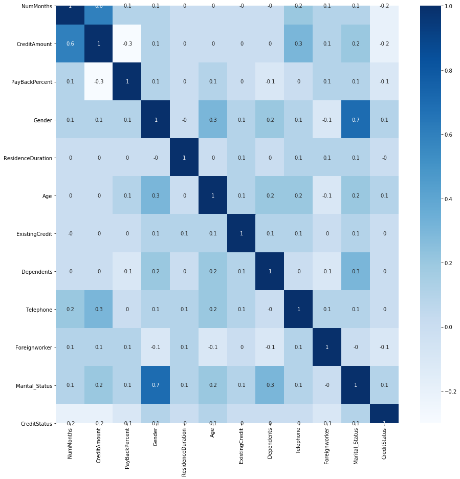

```python
plt.figure(figsize=(15,15))
sns.heatmap(corrMatrix, annot=True,cmap="Blues")
plt.show()
```

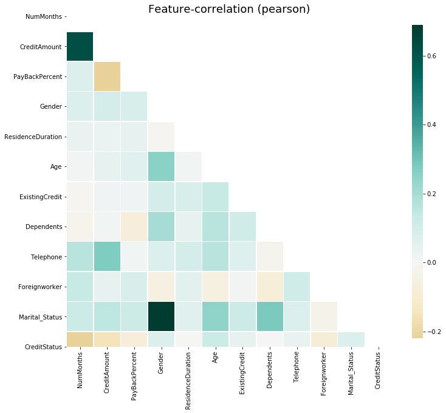

```python
klib.corr_plot(German_df,annot=False)
```

#### Observation:There is a good correlation between gender and marital status ; credit amount and number of months

#### Correlation w.r.to target field

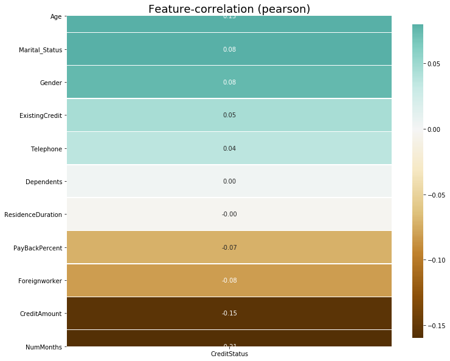

```python
klib.corr_plot(German_df,target='CreditStatus')
```

```python
klib.corr_mat(German_df)
```

|  | NumMonths | CreditAmount | PayBackPercent | Gender | ResidenceDuration | Age | ExistingCredit | Dependents | Telephone | Foreignworker | Marital_Status | CreditStatus |
| --- | --- | --- | --- | --- | --- | --- | --- | --- | --- | --- | --- | --- |
| NumMonths | 1.00 | 0.62 | 0.07 | 0.08 | 0.03 | 0.01 | -0.01 | -0.02 | 0.16 | 0.14 | 0.12 | -0.21 |
| CreditAmount | 0.62 | 1.00 | -0.27 | 0.09 | 0.03 | 0.05 | 0.02 | 0.02 | 0.28 | 0.05 | 0.15 | -0.15 |
| PayBackPercent | 0.07 | -0.27 | 1.00 | 0.09 | 0.05 | 0.06 | 0.02 | -0.07 | 0.01 | 0.09 | 0.12 | -0.07 |
| Gender | 0.08 | 0.09 | 0.09 | 1.00 | -0.01 | 0.25 | 0.09 | 0.20 | 0.08 | -0.05 | 0.74 | 0.08 |
| ResidenceDuration | 0.03 | 0.03 | 0.05 | -0.01 | 1.00 | 0.01 | 0.09 | 0.04 | 0.10 | 0.05 | 0.06 | -0.00 |
| Age | 0.01 | 0.05 | 0.06 | 0.25 | 0.01 | 1.00 | 0.14 | 0.17 | 0.16 | -0.05 | 0.25 | 0.13 |
| ExistingCredit | -0.01 | 0.02 | 0.02 | 0.09 | 0.09 | 0.14 | 1.00 | 0.11 | 0.07 | 0.01 | 0.12 | 0.05 |
| Dependents | -0.02 | 0.02 | -0.07 | 0.20 | 0.04 | 0.17 | 0.11 | 1.00 | -0.01 | -0.08 | 0.28 | 0.00 |
| Telephone | 0.16 | 0.28 | 0.01 | 0.08 | 0.10 | 0.16 | 0.07 | -0.01 | 1.00 | 0.11 | 0.08 | 0.04 |
| Foreignworker | 0.14 | 0.05 | 0.09 | -0.05 | 0.05 | -0.05 | 0.01 | -0.08 | 0.11 | 1.00 | -0.03 | -0.08 |
| Marital_Status | 0.12 | 0.15 | 0.12 | 0.74 | 0.06 | 0.25 | 0.12 | 0.28 | 0.08 | -0.03 | 1.00 | 0.08 |
| CreditStatus | -0.21 | -0.15 | -0.07 | 0.08 | -0.00 | 0.13 | 0.05 | 0.00 | 0.04 | -0.08 | 0.08 | 1.00 |

```
GridSpec(6, 9)
```

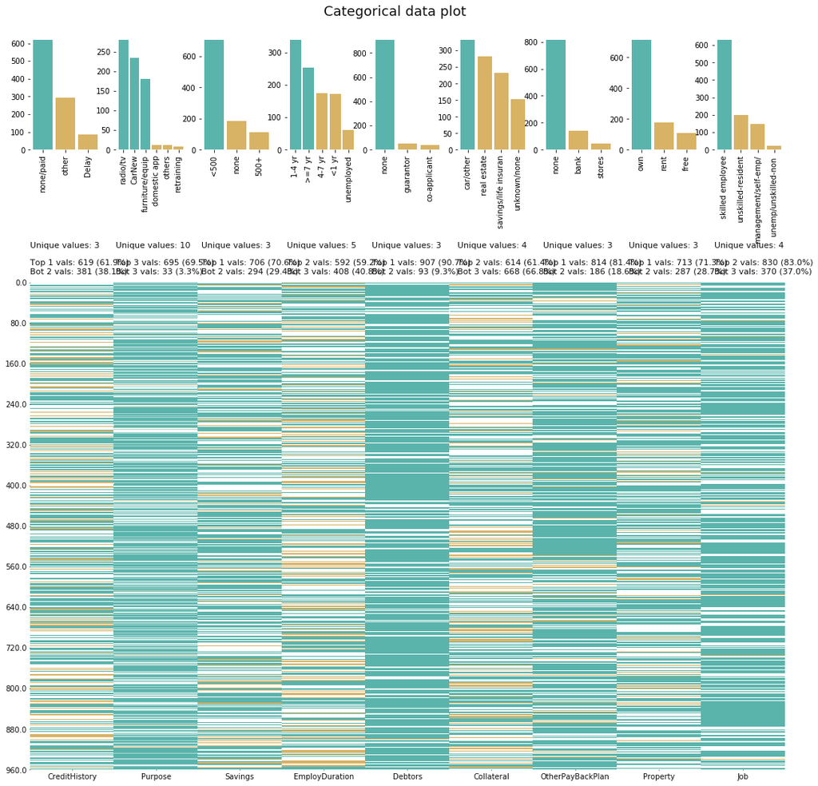

```python
klib.cat_plot(German_df)
```

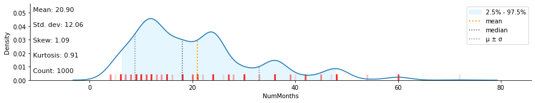

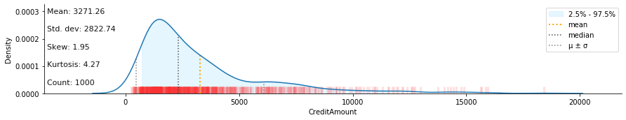

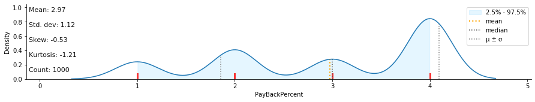

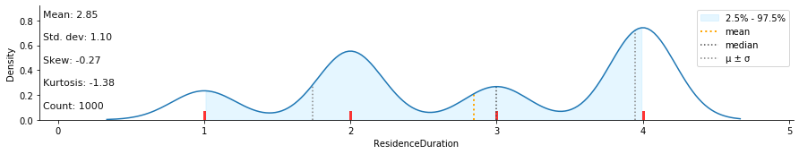

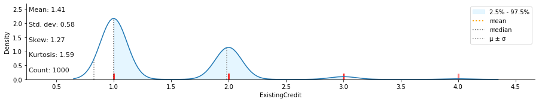

```python
klib.dist_plot(German_df)
```

```
1    810
0    190
Name: Age, dtype: int64
```

```
 <a list of 2 Text xticklabel objects>)
```

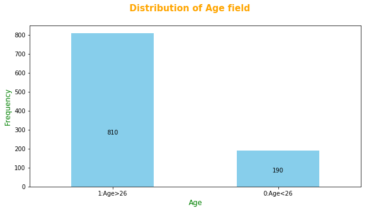

```python
import matplotlib.pyplot as plt

import numpy as np

age_count=German_df.Age.value_counts(sort=True)

print(age_count)

plt.figure(figsize=(10,5))

age_count.plot(kind='bar', color='skyblue', rot=0)

plt.ylabel('Frequency',fontsize=12,color='green')

plt.xlabel('Age',fontsize=12,color='green')

plt.suptitle('Distribution of Age field',fontsize=15,color='orange',fontweight='bold')

plt.annotate(age_count[1],xy=(0,300),verticalalignment="top",horizontalalignment="center")
plt.annotate(age_count[0],xy=(1,100),verticalalignment="top",horizontalalignment="center")

LABELS=["1:Age>26","0:Age<26"]
plt.xticks(range(2),LABELS)
```

#### Observation:There are more entries having age greater than 26yrs

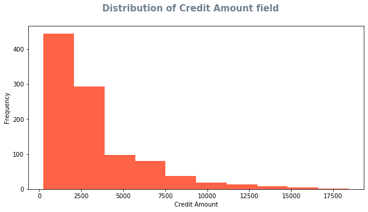

```python
plt.figure(figsize=(10,5))

plt.hist(German_df.CreditAmount, color='tomato')

plt.ylabel('Frequency')

plt.xlabel('Credit Amount')

plt.suptitle('Distribution of Credit Amount field',fontsize=15,color='slategrey',fontweight='bold')
```

#### Observation:There are more entries having lower credit amount that higher credit amount

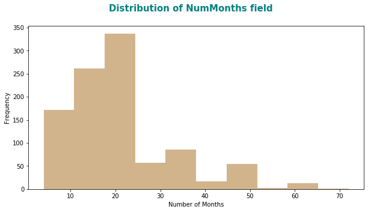

```python
plt.figure(figsize=(10,5))

plt.hist(German_df.NumMonths, color='tan')

plt.ylabel('Frequency')

plt.xlabel('Number of Months')

plt.suptitle('Distribution of NumMonths field',fontsize=15,color='teal',fontweight='bold')
```

#### Observation:There are more entries having lower duration than higher duration in months

```
1    700
0    300
Name: CreditStatus, dtype: int64
```

```
 <a list of 2 Text xticklabel objects>)
```

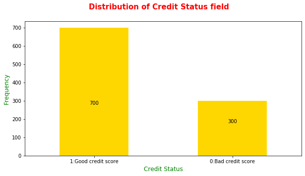

```python
target_count=German_df.CreditStatus.value_counts(sort=True)

print(target_count)

plt.figure(figsize=(10,5))

target_count.plot(kind='bar', color='gold', rot=0)

plt.ylabel('Frequency',fontsize=12,color='green')

plt.xlabel('Credit Status',fontsize=12,color='green')

plt.suptitle('Distribution of Credit Status field',fontsize=15,color='red',fontweight='bold')

plt.annotate(target_count[1],xy=(0,300),verticalalignment="top",horizontalalignment="center")
plt.annotate(target_count[0],xy=(1,200),verticalalignment="top",horizontalalignment="center")

LABELS=["1:Good credit score","0:Bad credit score"]
plt.xticks(range(2),LABELS)
```

#### Observation:There are more entries having good credit score than bad credit score

```python
German_df['Age'].describe()
```

```
count    1000.000000
mean        0.810000
std         0.392497
min         0.000000
25%         1.000000
50%         1.000000
75%         1.000000
max         1.000000
Name: Age, dtype: float64
```

```python
German_df.Gender.unique()
```

```
array([1, 0], dtype=int64)
```

```
1    690
0    310
Name: Gender, dtype: int64
```

```
 <a list of 2 Text xticklabel objects>)
```

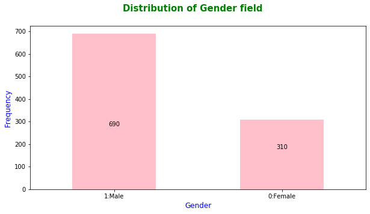

```python
Gender_count=German_df.Gender.value_counts()
print(Gender_count)

plt.figure(figsize=(10,5))

Gender_count.plot(kind='bar', color='pink', rot=0)

plt.ylabel('Frequency',fontsize=12,color='blue')

plt.xlabel('Gender',fontsize=12,color='blue')

plt.suptitle('Distribution of Gender field',fontsize=15,color='Green',fontweight='bold')

plt.annotate(Gender_count[1],xy=(0,300),verticalalignment="top",horizontalalignment="center")
plt.annotate(Gender_count[0],xy=(1,200),verticalalignment="top",horizontalalignment="center")

LABELS=["1:Male","0:Female"]
plt.xticks(range(2),LABELS)
```

```
1    548
0    452
Name: Marital_Status, dtype: int64
```

```
 <a list of 2 Text xticklabel objects>)
```

[figure not shown]

```python
ms_count=German_df.Marital_Status.value_counts()
print(ms_count)

plt.figure(figsize=(10,5))

ms_count.plot(kind='bar', color='orange', rot=0)

plt.ylabel('Frequency',fontsize=12,color='blue')

plt.xlabel('Marital Status',fontsize=12,color='blue')

plt.suptitle('Distribution of Marital Status field',fontsize=15,color='brown',fontweight='bold')

plt.annotate(Gender_count[1],xy=(0,300),verticalalignment="top",horizontalalignment="center")
plt.annotate(Gender_count[0],xy=(1,200),verticalalignment="top",horizontalalignment="center")

LABELS=["1:Single","0:Not single"]
plt.xticks(range(2),LABELS)
```

#### Observation:There are more male entries than female entries

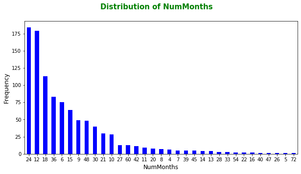

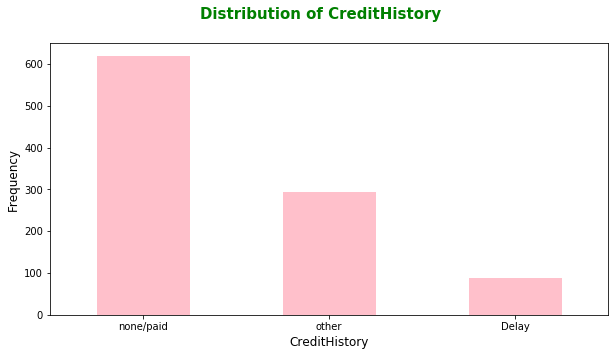

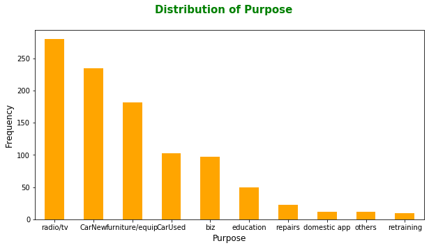

[figure not shown]

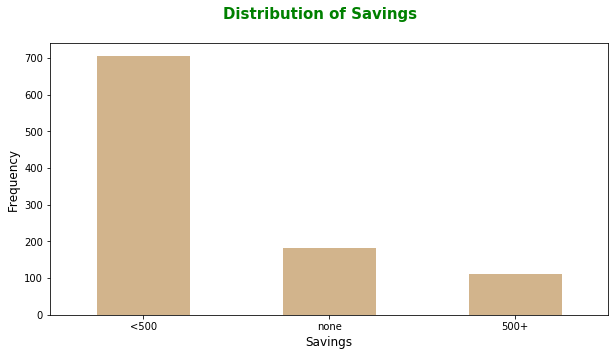

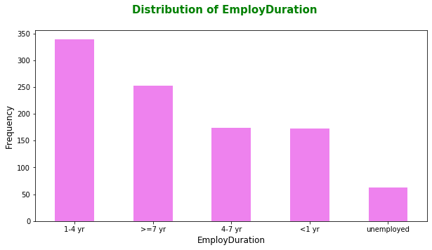

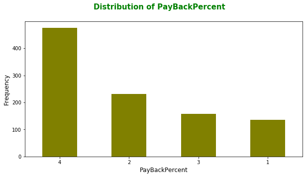

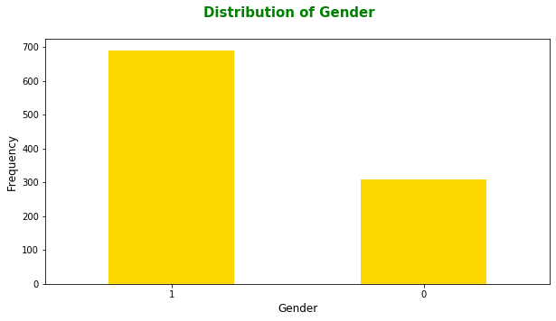

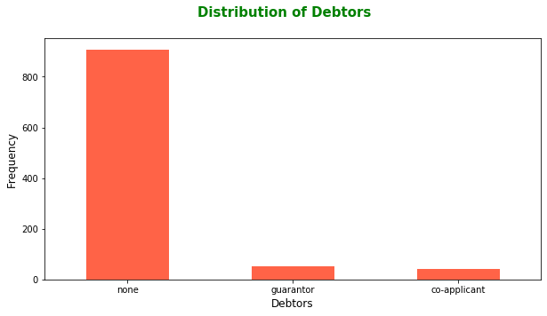

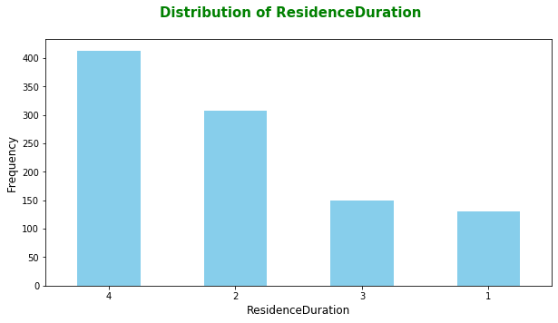

```python
colour=['blue','pink','orange','green','tan','violet','olive','gold','tomato','skyblue']
for i,j in zip(German_df.columns,colour):
    field_count=German_df[i].value_counts()
    #print(field_count)

    plt.figure(figsize=(10,5))

    field_count.plot(kind='bar', color=j, rot=0)

    plt.ylabel('Frequency',fontsize=12,color='black')

    plt.xlabel(i,fontsize=12,color='black')

    plt.suptitle('Distribution of '+ i,fontsize=15,color='Green',fontweight='bold')
```